# Mini Project 1 Initial Submission

Ruchik Rohit Dama,Aniket Kale, Shashank Kumar, Sumanth Gopalkrishna

9/29/2021

## Question 1

### Load the data

```r
cpi_data=read_xls("State_and_US_SA.xls", range = 'A6:BA546', col_names = TRUE)
cpi_data1=read_xls("State_and_US_SA.xls", range = 'A6:BA546', col_names = TRUE)
cpi=read.csv(file = 'cpi.csv')
```

```r
col_2019=subset(cpi, cpi$Year == 2019)
vals=col_2019$Value
cpi$denom <- rep(vals, times = 73)
#head(cpi)
```

### Removed the data prior to 1975.

```r
cpi=cpi[which(cpi$Year>1974),]
#head(cpi)
```

### Splitted the month column and stored it in the Month and Year Columns

```r
#cpi=cpi[which(Year>1974)]
cpi_temp=str_split_fixed(cpi_data$Month, "M", 2)
cpi_data$Year=as.numeric(cpi_temp[,1])
cpi_data$Month=as.numeric(cpi_temp[,2])
#head(cpi_data)
```

```r
cpi_data1$Year=as.numeric(cpi_temp[,1])
cpi_data1$Month=as.numeric(cpi_temp[,2])
#head(cpi_data)
```

### Merging cpi_data and cpi dateset

```r
cpi_data = merge(cpi_data, cpi, by = "Year",inplace=TRUE)
#tail(cpi_data)
```

### Renaming United States seasonally adjusted to usprice

```r
colnames(cpi_data)[colnames(cpi_data) == "United States seasonally adjusted"] = "usprice"
#head(cpi_data)
```

```r
cpi_data[,3:53] = (cpi_data[,3:53] * cpi_data$denom) / cpi_data$Value
#head(cpi_data)
```

```r
cpi_data$usprice = (cpi_data$usprice * cpi_data$denom) / cpi_data$Value
#head(cpi_data)
```

### Question 1.1:- How have house prices in the U.S changed since 1975, afteradjusting for inflation (i.e. relative to the CPI?)

### Plloting the graph between years v/s change in value before and after adjusting inflation.

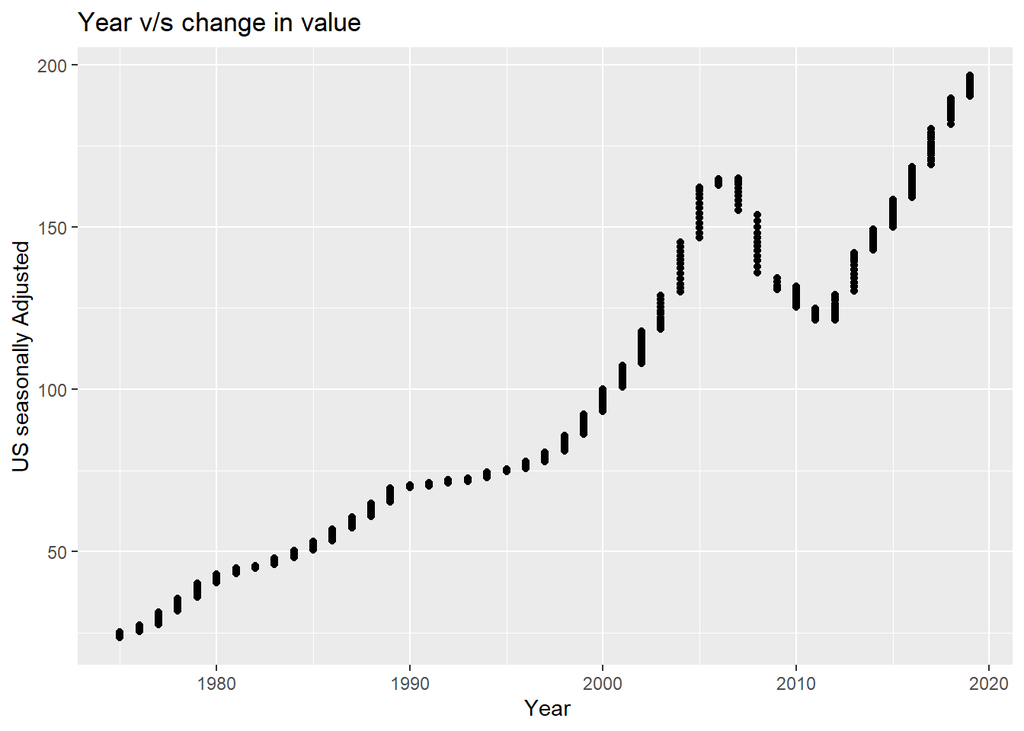

```r
ggplot(cpi_data1,aes(x = Year , y = `United States seasonally adjusted`))+geom_point()+labs(title = "Year v/s change in value",x=" Year",y="US seasonally Adjusted")
```

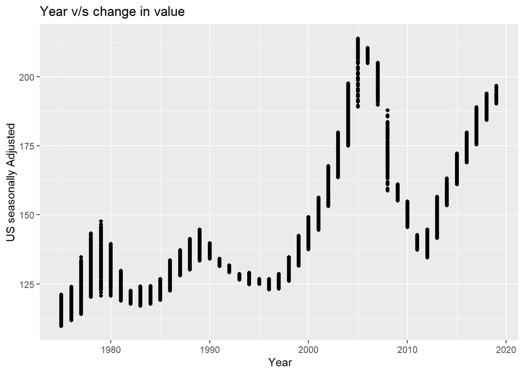

```r
ggplot(cpi_data,aes(x = Year , y = usprice))+geom_point()+labs(title = "Year v/s change in value",x=" Year",y="US seasonally Adjusted")  #+stat_smooth(method='lm', se = FALSE)
```

```r
state_codes_df = read.delim(file = "statecodes.txt", header = FALSE, sep = "", dec = ".")
#tail(state_codes_df)
```

### Removing the last value.

```r
state_codes=state_codes_df$V2[-c(52)]
#length(state_codes)
```

### Pivoting the data from wide to long.

```r
state_data=cpi_data[1:53]
state_data <- state_data[-c(2)]
state_data1=state_data %>%
 pivot_longer(
   cols =state_codes,
   names_to = "variable",
   values_to = "value",
   values_drop_na = TRUE
 )
```

```
## Note: Using an external vector in selections is ambiguous.
## i Use `all_of(state_codes)` instead of `state_codes` to silence this message.
## i See <https://tidyselect.r-lib.org/reference/faq-external-vector.html>.
```

```r
#head(state_data1)
```

### Finding the mean of values.

```r
state_mean=aggregate(value~variable + Year,data=state_data1,mean)
#head(state_mean,50)
```

### How have changes in prices varied by state?

### Plotting graphs for each state

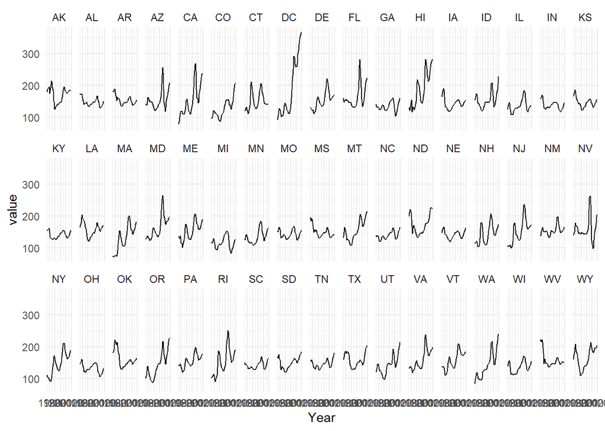

```r
state_plot <- ggplot(state_mean, aes(x=Year, y = value)) + geom_line()
state_plot + facet_wrap(~variable, ncol = 17)  + theme_minimal()
```

The state wise plots for house prices vs timeline are as above. They pretty much follow similar behaviour as we saw in the previous plot. Although, we do see certain states which have a sudden rise like DC i.e. District of Columbia.

### States with Biggest Increases

### Plotting graphs of top 4 states with biggest increases

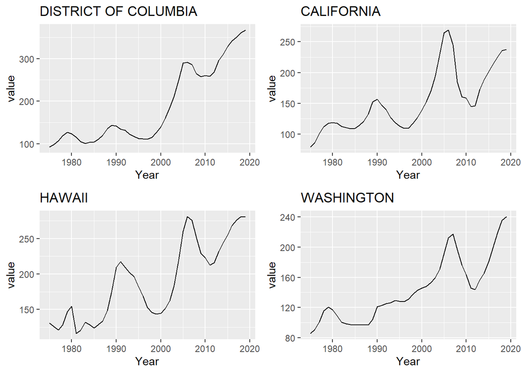

```r
#state_plot <- ggplot(state_mean, aes(x=Year, y = value)) + geom_line()
#state_plot + facet_wrap(~variable, ncol = 7)  + theme_minimal()
dc_df = subset(state_mean, state_mean$variable == "DC")
cal_df = subset(state_mean, state_mean$variable == "CA")
hi_df = subset(state_mean, state_mean$variable == "HI")
wa_df = subset(state_mean, state_mean$variable == "WA")
g1 = ggplot(dc_df, aes(x = Year, y = value)) + geom_line() + ggtitle("DISTRICT OF COLUMBIA")
g2 = ggplot(cal_df, aes(x = Year, y = value)) + geom_line() + ggtitle("CALIFORNIA")
g3 = ggplot(hi_df, aes(x = Year, y = value)) + geom_line() + ggtitle("HAWAII")
g4 = ggplot(wa_df, aes(x = Year, y = value)) + geom_line() + ggtitle("WASHINGTON")
grid.arrange(g1,g2,g3,g4, nrow = 2)
```

[figure not shown]

```r
ak_df = subset(state_mean, state_mean$variable == "AK")
oh_df = subset(state_mean, state_mean$variable == "OH")
ok_df = subset(state_mean, state_mean$variable == "OK")
wv_df = subset(state_mean, state_mean$variable == "WV")
g1 = ggplot(ak_df, aes(x = Year, y = value)) + geom_line() + ggtitle("ARKANSAS")
g2 = ggplot(oh_df, aes(x = Year, y = value)) + geom_line() + ggtitle("OHIO")
g3 = ggplot(ok_df, aes(x = Year, y = value)) + geom_line() + ggtitle("OKLOHOMA")
g4 = ggplot(wv_df, aes(x = Year, y = value)) + geom_line() + ggtitle("WEST VIRGINIA")
grid.arrange(g1,g2,g3,g4, nrow = 2)
```

### Grpah for 4 regions namely:-

### Plotting graphs of west, midwest, northeast and south states.

```r
west_states = c("WA", "MT", "OR", "ID", "WY", "CA", "NV", "UT", "CO", "AZ", "NM", "HI")
midwest_states = c("ND", "MN", "SD", "NE", "IA", "KS", "MO", "WI", "MI", "IL", "IN", "OH")
northeast_states = c("PA", "NJ", "NY", "CT", "RI", "MA", "VT", "NH", "ME")
south_states = c("OK", "TX", "AR", "LA", "MS", "AL", "TM", "KY", "GA", "FL", "SC", "NC", "WV", "VA", "DC", "MD", "DE")
west_data = state_mean[state_mean$variable %in% west_states,]
midwest_data = state_mean[state_mean$variable %in% midwest_states,]
northeast_data = state_mean[state_mean$variable %in% northeast_states,]
south_data = state_mean[state_mean$variable %in% south_states,]
```

```r
west_mean=aggregate(value~Year,data=west_data,mean)
midwest_mean=aggregate(value~Year,data=midwest_data,mean)
northeast_mean=aggregate(value~Year,data=northeast_data,mean)
south_mean=aggregate(value~Year,data=south_data,mean)
#south_mean
```

[figure not shown]

```r
g1 = ggplot(west_mean, aes(x = Year, y = value)) + geom_line() + ggtitle("WEST")
g2 = ggplot(west_mean, aes(x = Year, y = value)) + geom_line() + ggtitle("MIDWEST")
g3 = ggplot(northeast_mean, aes(x = Year, y = value)) + geom_line() + ggtitle("NORTHEAST")
g4 = ggplot(south_mean, aes(x = Year, y = value)) + geom_line() + ggtitle("SOUTH")
grid.arrange(g1,g2,g3,g4, nrow = 2)
```

The regions also pretty much follow the same trend as the overall house prices. Northeast region has a gradual rise and so does the West region. The period 1980-1990 was a consistently low patch for all except the Northeast region.

### Part 2:

```r
# import libararies

library(tidyverse)
library(broom)
library(readxl)
library(tidycensus)
library(arm)
library(MASS)
#census_api_key("10f0d49b7a43755878e4706e12c9b552b96428f7")
```

```r
#read data files
cpi = read.csv("cpi.csv")
pop = read.csv("population.csv")
areas = read.csv("https://raw.githubusercontent.com/jakevdp/data-USstates/master/state-areas.csv", stringsAsFactors=FALSE, fileEncoding="latin1")

scode = read.delim("statecodes.txt", header=F, sep=" ")
hpi = read_excel("State_and_US_SA.xls", skip=5)
```

```r
# loading tidycensus data
# census20 =  get_decennial(geography = "state",
#                        variables = "P001001",
#                        year = 2020)
# census10 =  get_decennial(geography = "state",
#                        variables = "P001001",
#                        year = 2010)
# census00 =  get_decennial(geography = "state",
#                        variables = "P001001",
#                        year = 2000)
# census90 = get_decennial(geography = "state",
#                        variables = "P0010001",
#                        year = 1990)
# View(census10)
```

```r
# head(areas)

# density.00 = merge(
#   x=census00,
#   y=areas,
#   by.x="NAME", by.y="state")
# density.00 = density.00%>%
#   mutate(density = value/area..sq..mi.)
```

```r
# Pre-process population df
names(pop)[2] = "state"
names(pop)[5] = "total.1970"
names(pop)[6] = "total.1980"
names(pop)[7] = "total.1990"
names(pop)[8] = "total.2000"
names(pop)[9] = "total.2010"
names(pop)[10] = "total.2008.2012"
pop = pop[,c( "state",
              "total.1970",
              "total.1980",
              "total.1990",
              "total.2000",
              "total.2010",
              "total.2008.2012"
              )]
# head(pop)
```

```r
# computing population density for all the states, after merging with areas df
pop.density = merge(
  x=pop,
  y=areas,
  by.x="state", by.y="state")

pop.density = pop.density %>%
  mutate(desity.1970 = total.1970/area..sq..mi.,
        desity.1980 = total.1980/area..sq..mi.,
        desity.1990 = total.1990/area..sq..mi.,
        desity.2000 = total.2000/area..sq..mi.,
        desity.2010 = total.2010/area..sq..mi.,
        desity.2008.2012 = total.2008.2012/area..sq..mi.
)
pop.density = merge(
  x=pop.density%>% mutate(state = toupper(state)),
  y=scode,
  by.x="state", by.y="V3")
# pop.density
```

```r
pop.density = dplyr::select(pop.density, -c("V1", "V4", "V5"))
names(pop.density)[length(names(pop.density))] = "ST"
# head(pop.density)
```

```r
hpi.dec = hpi %>% filter(
  Month %in% c("1980M12", "1990M12", "2000M12", "2010M12", "2019M12")
)
```

```r
scode = scode %>% filter(
  V2 != ""
)
print("Updated rows:")
```

```
## [1] "Updated rows:"
```

```r
print(nrow(scode))
```

```
## [1] 52
```

```r
hpi.dec.t = as.data.frame(t(hpi.dec))
names(hpi.dec.t) <- as.matrix(hpi.dec.t[1, ])
hpi.dec.t <- hpi.dec.t[-1, ]
hpi.dec.t[] <- lapply(hpi.dec.t, function(x) type.convert(as.character(x)))
hpi.dec.t <- cbind(ST = rownames(hpi.dec.t), hpi.dec.t)
rownames(hpi.dec.t) <- 1:nrow(hpi.dec.t)
# head(hpi.dec.t)
```

```r
pop.hpi.merged = merge(
  x=hpi.dec.t,
  y=pop.density,
  by.x="ST", by.y="ST")
names(pop.hpi.merged)[2] = "hpi.1980"
names(pop.hpi.merged)[3] = "hpi.1990"
names(pop.hpi.merged)[4] = "hpi.2000"
names(pop.hpi.merged)[5] = "hpi.2010"
names(pop.hpi.merged)[6] = "hpi.2019"

# head(pop.hpi.merged)
```

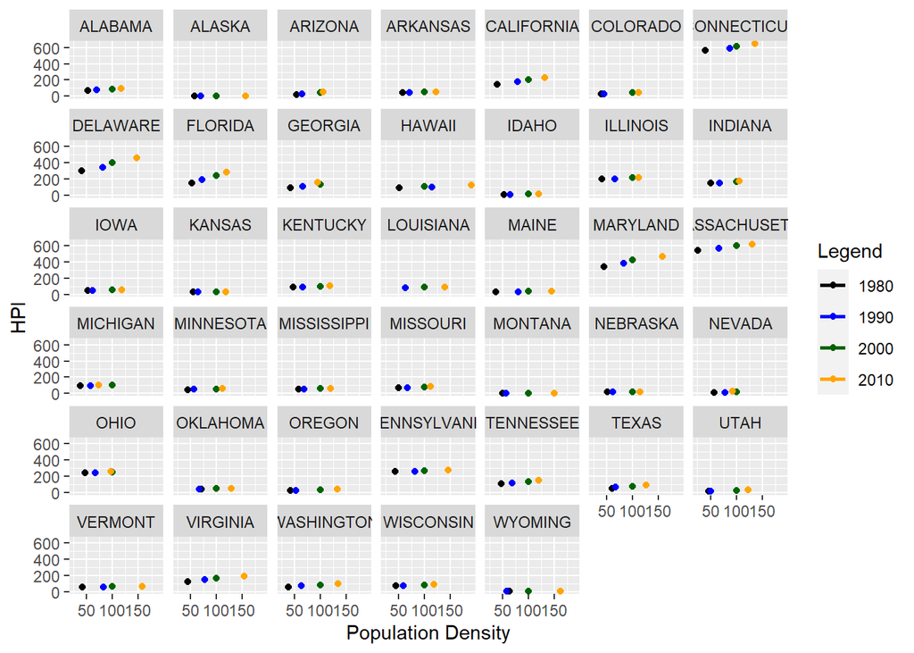

```r
colors <- c("1980" = "black", "1990" = "blue", "2000" = "darkgreen", "2010" = "orange")

pop.hpi.merged %>%
  ggplot(aes(x=hpi.1980, y =desity.1980, color="1980")) +geom_point() +
  geom_point(data = pop.hpi.merged, aes(x=hpi.1990, y =desity.1990, col = "1990"))+
  geom_point(data = pop.hpi.merged, aes(x=hpi.2000, y =desity.2000, col = "2000"))+
  geom_point(data = pop.hpi.merged, aes(x=hpi.2010, y =desity.2010, col = "2010"))+
  labs(y = "HPI",
         x = "Population Density",
         color = "Legend")+
    scale_color_manual(values = colors)+
  geom_smooth(method = "lm" ,se=F)+
  geom_smooth(method = "lm" ,se=F,data = pop.hpi.merged, aes(x=hpi.1990, y =desity.1990, col = "1990"))+
  geom_smooth(method = "lm" ,se=F,data = pop.hpi.merged, aes(x=hpi.2000, y =desity.2000, col = "2000"))+
  geom_smooth(method = "lm" ,se=F,data = pop.hpi.merged, aes(x=hpi.2010, y =desity.2010, col = "2010"))+
  facet_wrap(~state)
```

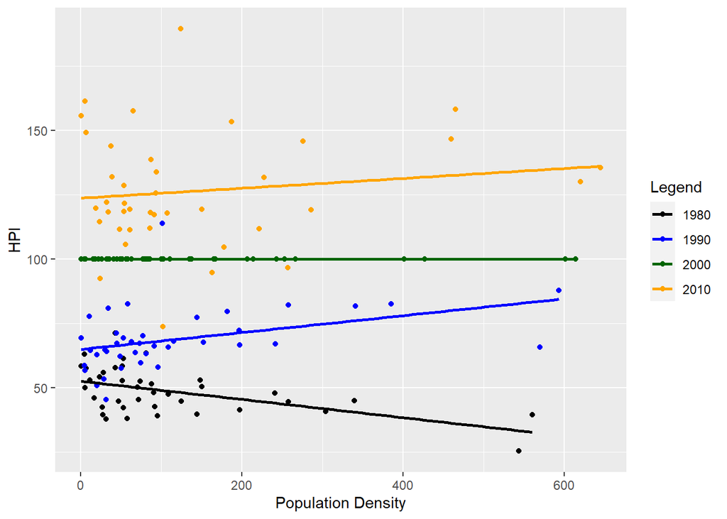

```r
colors <- c("1980" = "black", "1990" = "blue", "2000" = "darkgreen", "2010" = "orange")

pop.hpi.merged %>%
  ggplot(aes(y=hpi.1980, x =desity.1980, color="1980")) +
  geom_point() +
  geom_point(data = pop.hpi.merged, aes(y=hpi.1990, x =desity.1990, col = "1990"))+
  geom_point(data = pop.hpi.merged, aes(y=hpi.2000, x =desity.2000, col = "2000"))+
  geom_point(data = pop.hpi.merged, aes(y=hpi.2010, x =desity.2010, col = "2010"))+
  labs(y = "HPI",
         x = "Population Density",
         color = "Legend")+
    scale_color_manual(values = colors)+
  geom_smooth(method = "lm" ,se=F)+
  geom_smooth(method = "lm" ,se=F,data = pop.hpi.merged, aes(y=hpi.1990, x =desity.1990, col = "1990"))+
  geom_smooth(method = "lm" ,se=F,data = pop.hpi.merged, aes(y=hpi.2000, x =desity.2000, col = "2000"))+
  geom_smooth(method = "lm" ,se=F,data = pop.hpi.merged, aes(y=hpi.2010, x =desity.2010, col = "2010"))
```

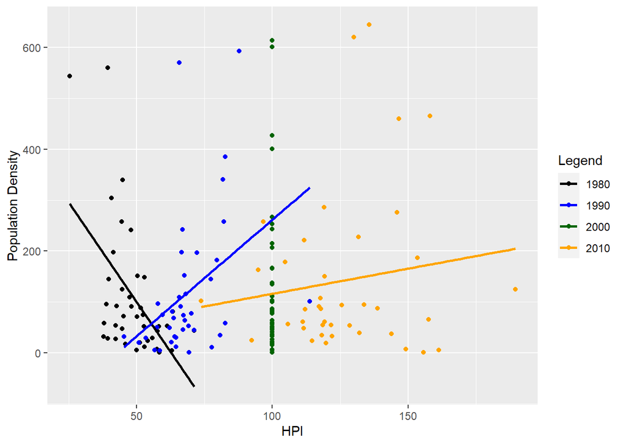

```r
colors <- c("1980" = "black", "1990" = "blue", "2000" = "darkgreen", "2010" = "orange")

pop.hpi.merged %>%
  ggplot(aes(x=hpi.1980, y =desity.1980, color="1980")) +
  geom_point() +
  geom_point(data = pop.hpi.merged, aes(x=hpi.1990, y =desity.1990, col = "1990"))+
  geom_point(data = pop.hpi.merged, aes(x=hpi.2000, y =desity.2000, col = "2000"))+
  geom_point(data = pop.hpi.merged, aes(x=hpi.2010, y =desity.2010, col = "2010"))+
  labs(x = "HPI",
         y = "Population Density",
         color = "Legend")+
    scale_color_manual(values = colors)+
  geom_smooth(method = "lm" ,se=F)+
  geom_smooth(method = "lm" ,se=F,data = pop.hpi.merged, aes(x=hpi.1990, y =desity.1990, col = "1990"))+
  geom_smooth(method = "lm" ,se=F,data = pop.hpi.merged, aes(x=hpi.2000, y =desity.2000, col = "2000"))+
  geom_smooth(method = "lm" ,se=F,data = pop.hpi.merged, aes(x=hpi.2010, y =desity.2010, col = "2010"))
```

#### Outliers:

- There are two influencial outliers for every year.
- Instead of completely removing outliers, we can try to down weigh them. Because these points represent two states and they just cannot be eliminated.

```r
# finding outliers
pop.hpi.merged %>%
  filter(desity.1980>500 | desity.1990>500 | desity.2000>500 | desity.2010>500)
```

```
##   ST hpi.1980 hpi.1990 hpi.2000 hpi.2010 hpi.2019         state total.1970
## 1 CT 39.41607 87.69912      100 135.6046 140.0495   CONNECTICUT    3031709
## 2 MA 25.26031 65.64153      100 129.9945 186.7045 MASSACHUSETTS    5689170
##   total.1980 total.1990 total.2000 total.2010 total.2008.2012 area..sq..mi.
## 1    3107576    3287116    3405565    3574097         3572213          5544
## 2    5737037    6016425    6349097    6547629         6560595         10555
##   desity.1970 desity.1980 desity.1990 desity.2000 desity.2010 desity.2008.2012
## 1    546.8451    560.5296    592.9141    614.2794    644.6784         644.3386
## 2    539.0024    543.5374    570.0071    601.5251    620.3343         621.5628
```

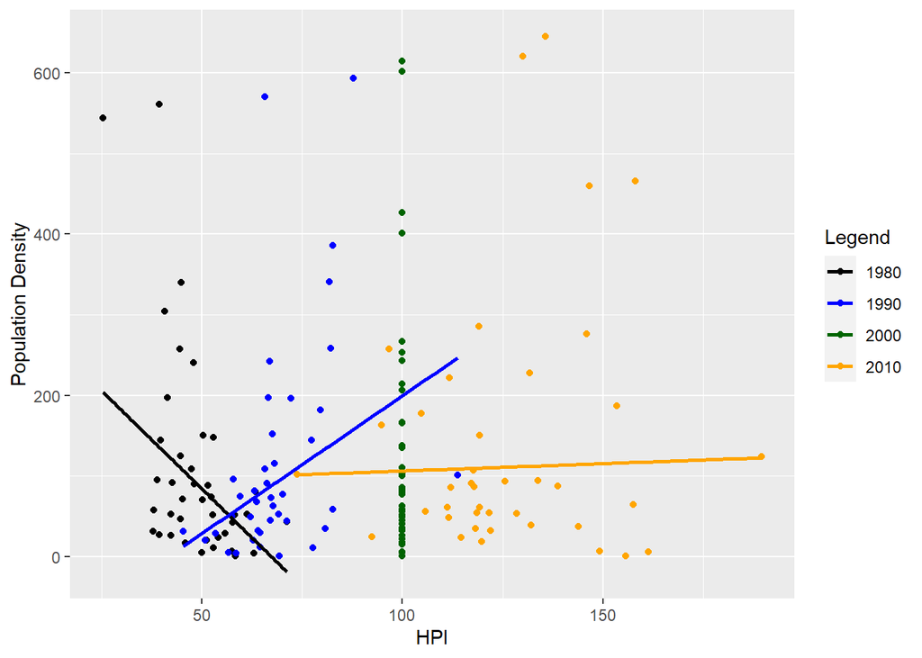

```r
# after using rlm
colors <- c("1980" = "black", "1990" = "blue", "2000" = "darkgreen", "2010" = "orange")

pop.hpi.merged %>%
  ggplot(aes(x=hpi.1980, y =desity.1980, color="1980")) +
  geom_point() +
  geom_point(data = pop.hpi.merged, aes(x=hpi.1990, y =desity.1990, col = "1990"))+
  geom_point(data = pop.hpi.merged, aes(x=hpi.2000, y =desity.2000, col = "2000"))+
  geom_point(data = pop.hpi.merged, aes(x=hpi.2010, y =desity.2010, col = "2010"))+
  labs(x = "HPI",
         y = "Population Density",
         color = "Legend")+
    scale_color_manual(values = colors)+
  geom_smooth(method = rlm ,se=F)+
  geom_smooth(method = rlm,method.args = list(psi.bisquare) ,se=F,data = pop.hpi.merged, aes(x=hpi.1990, y =desity.1990, col = "1990"))+
  geom_smooth(method = rlm,method.args = list(psi.bisquare) ,se=F,data = pop.hpi.merged, aes(x=hpi.2000, y =desity.2000, col = "2000"))+
  geom_smooth(method = rlm,method.args = list(psi.bisquare) ,se=F,data = pop.hpi.merged, aes(x=hpi.2010, y =desity.2010, col = "2010"))
```

### QUESTION 3:-

### Loading the Data

```r
population_2018 = get_acs(geography = "state",
              variables = c(Total = "B00001_001"),
              year = 2018)
population=read.csv(file = 'population.csv')
#(population)
```

```r
colnames(state_codes_df)[colnames(state_codes_df) == "V2"] <- "variable"

colnames(state_codes_df)[colnames(state_codes_df) == "V3"] <- "NAME"
state_codes_df$NAME <- toupper(state_codes_df$NAME)
```

```r
#head(state_codes_df)
```

### Storing the data for 2018, 2010, 2000, 1990 year.

```r
state_mean <- merge(state_mean, state_codes_df, by = "variable")
#head(state_mean)
```

```r
pop_10 <- subset(state_mean, state_mean$Year == 2010)
pop_90 <- subset(state_mean, state_mean$Year == 1990)
pop_00 <- subset(state_mean, state_mean$Year == 2000)
pop_18 <- subset(state_mean, state_mean$Year == 2018)
```

```r
colnames(population)[colnames(population) == "NHGIS.Integrated.State.Name"] <- "NAME"
#head(population)
population$NAME <- toupper(population$NAME)
```

```r
population_1990=population[c(2,7)]
population_2000=population[c(2,8)]
population_2010=population[c(2,9)]
#population_2018=population_2018[c(2,4)]
#head(population_1990)
```

```r
population_2018$NAME = toupper(population_2018$NAME)
#head(population_2018)
```

```r
#head(pop_10)
```

```r
colnames(population_1990)[colnames(population_1990) == "X1990..Persons..Total"] <- "Total_1990"
colnames(population_2000)[colnames(population_2000) == "X2000..Persons..Total"] <- "Total_2000"
colnames(population_2010)[colnames(population_2010) == "X2010..Persons..Total"] <- "Total_2010"
colnames(population_2018)[colnames(population_2018) == "estimate"] <- "Total_2018"
```

### Merging datasets to get a common dataset for each year.

```r
data_10 <- merge(pop_10, population_2010, by = "NAME")
data_00 <- merge(pop_00, population_2000, by = "NAME")
data_90 <- merge(pop_90, population_1990, by = "NAME")
data_18 <- merge(pop_18, population_2018, by = "NAME")
```

```r
colnames(pop_90)[colnames(pop_90) == "V3"] <- "NAME"
colnames(pop_00)[colnames(pop_00) == "V3"] <- "NAME"
colnames(pop_10)[colnames(pop_10) == "V3"] <- "NAME"
```

```r
data_18=data_18[c("NAME","value","Total_2018")]
data_00=data_00[c("NAME","value","Total_2000")]
data_10=data_10[c("NAME","value","Total_2010")]
data_90=data_90[c("NAME","value","Total_1990")]
```

### Finding change in house prices and change in population.

```r
data_10$pdiff <- data_10$Total_2010 - data_00$Total_2000
data_18$pdiff <- data_18$Total_2018 - data_10$Total_2010
data_00$pdiff <- data_00$Total_2000 - data_90$Total_1990
data_10$diff <- data_10$value - data_00$value
data_18$diff <- data_18$value - data_10$value
data_00$diff <- data_00$value - data_90$value
```

```r
#head(data_00)
```

### Plotting the graphs for change in house price and population

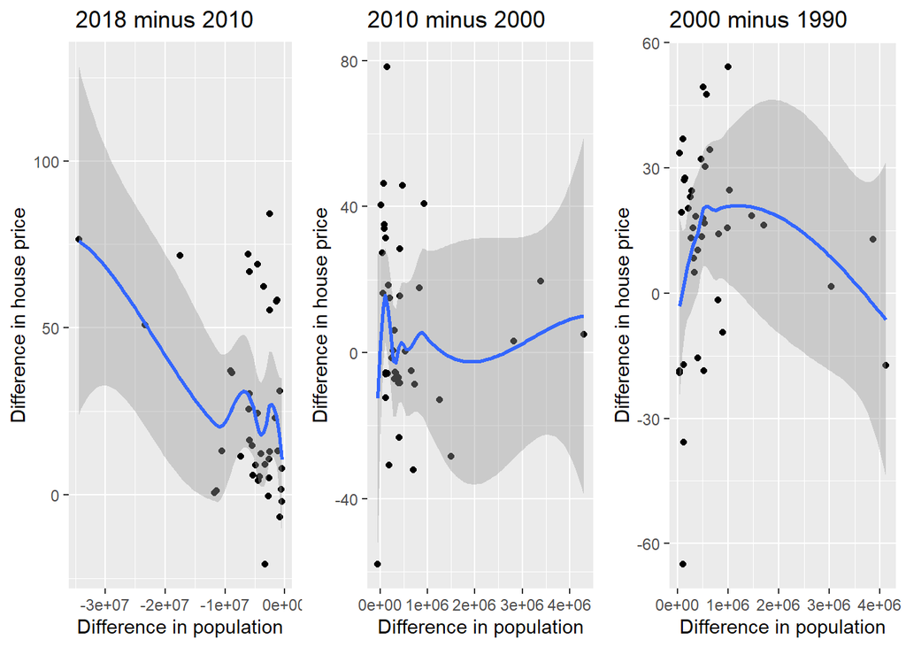

```r
g1 = ggplot(data_18, aes(x = pdiff, y = diff)) + geom_point() + xlab("Difference in population") + ylab("Difference in house price") + ggtitle(" 2018 minus 2010")+geom_smooth()

g2 = ggplot(data_10, aes(x = pdiff, y = diff)) + geom_point() + xlab("Difference in population") + ylab("Difference in house price") + ggtitle("2010 minus 2000")+geom_smooth()

g3 = ggplot(data_00, aes(x = pdiff, y = diff)) + geom_point() + xlab("Difference in population") + ylab("Difference in house price") + ggtitle("2000 minus 1990")+geom_smooth()

grid.arrange(g1,g2,g3, nrow = 1)
```

```r
data_18 = merge(data_18, state_codes_df, by = "NAME")
data_10 = merge(data_10, state_codes_df, by = "NAME")
data_00 = merge(data_00, state_codes_df, by = "NAME")
data_90 = merge(data_90, state_codes_df, by = "NAME")
```

```r
west_df = data_18[data_18$variable %in% west_states,]
midwest_df = data_18[data_18$variable %in% midwest_states,]
northeast_df = data_18[data_18$variable %in% northeast_states,]
south_df = data_18[data_18$variable %in% south_states,]
```

### plotting the graphs for west, midwest, northeast, south for change in house prices and population for every year.

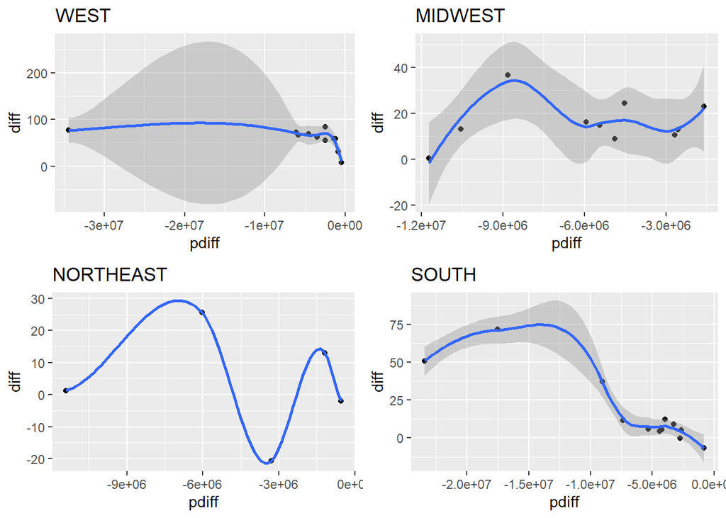

```r
g1 = ggplot(west_df, aes(x = pdiff, y = diff)) + geom_point() + ggtitle("WEST") +geom_smooth()
g2 = ggplot(midwest_df, aes(x = pdiff, y = diff)) + geom_point() + ggtitle("MIDWEST")+geom_smooth()
g3 = ggplot(northeast_df, aes(x = pdiff, y = diff)) + geom_point() + ggtitle("NORTHEAST")+geom_smooth()
g4 = ggplot(south_df, aes(x = pdiff, y = diff)) + geom_point() + ggtitle("SOUTH")+geom_smooth()
grid.arrange(g1,g2,g3,g4, nrow = 2)
```

```r
west_df = data_10[data_10$variable %in% west_states,]
midwest_df = data_10[data_10$variable %in% midwest_states,]
northeast_df = data_10[data_10$variable %in% northeast_states,]
south_df = data_10[data_10$variable %in% south_states,]
```

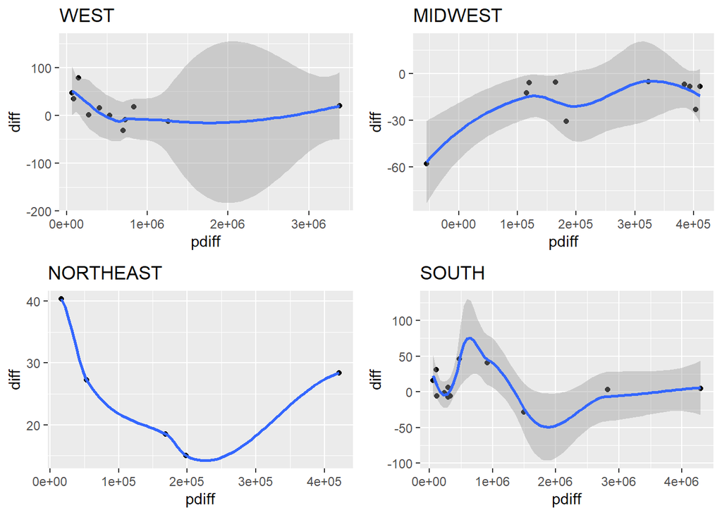

```r
g1 = ggplot(west_df, aes(x = pdiff, y = diff)) + geom_point() + ggtitle("WEST") +geom_smooth()
g2 = ggplot(midwest_df, aes(x = pdiff, y = diff)) + geom_point() + ggtitle("MIDWEST")+geom_smooth()
g3 = ggplot(northeast_df, aes(x = pdiff, y = diff)) + geom_point() + ggtitle("NORTHEAST")+geom_smooth()
g4 = ggplot(south_df, aes(x = pdiff, y = diff)) + geom_point() + ggtitle("SOUTH")+geom_smooth()
grid.arrange(g1,g2,g3,g4, nrow = 2)
```

```r
west_df = data_00[data_10$variable %in% west_states,]
midwest_df = data_00[data_00$variable %in% midwest_states,]
northeast_df = data_00[data_00$variable %in% northeast_states,]
south_df = data_00[data_00$variable %in% south_states,]
```

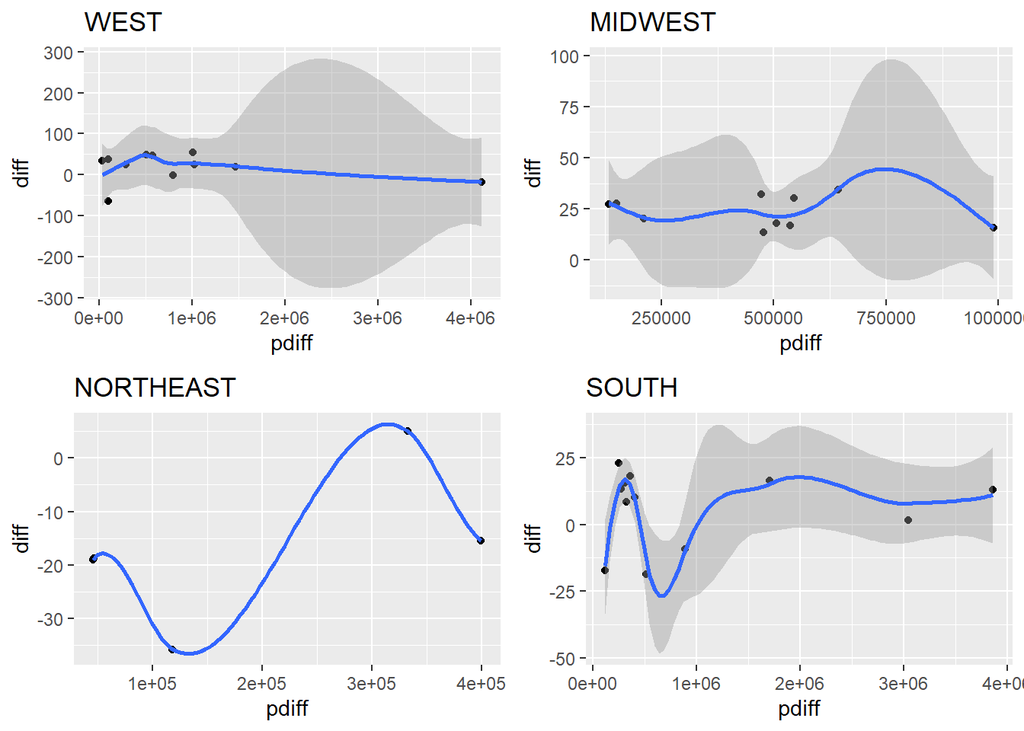

```r
g1 = ggplot(west_df, aes(x = pdiff, y = diff)) + geom_point() + ggtitle("WEST") +geom_smooth()
g2 = ggplot(midwest_df, aes(x = pdiff, y = diff)) + geom_point() + ggtitle("MIDWEST")+geom_smooth()
g3 = ggplot(northeast_df, aes(x = pdiff, y = diff)) + geom_point() + ggtitle("NORTHEAST")+geom_smooth()
g4 = ggplot(south_df, aes(x = pdiff, y = diff)) + geom_point() + ggtitle("SOUTH")+geom_smooth()
grid.arrange(g1,g2,g3,g4, nrow = 2)
```